# 3 Plotting & Data Visualisation

## 3.15 Geographic maps with GeoMakie

So far every plot has used plain numeric axes — “Easting (km)” and “Northing (km).” But geoscientists often need to plot data on a **map** with coastlines, country borders, and a proper geographic projection. That is what **GeoMakie.jl** gives you.

GeoMakie provides a `GeoAxis`, a drop-in replacement for Makie’s `Axis` that understands coordinate reference systems (CRS) and projections. You feed it longitude/latitude data and tell it which projection you want; it handles the transformation and draws graticules automatically.

### 3.15.1 Installing GeoMakie

```
pkg> add GeoMakie
```

Or: `using Pkg; Pkg.add("GeoMakie")`. GeoMakie pulls in Proj.jl (for map projections) and NaturalEarth (for coastlines and country boundaries).

```julia
using GeoMakie
```

### 3.15.2 A world map in three lines

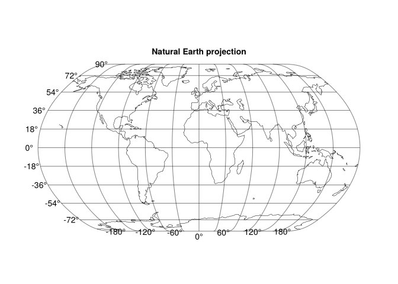

```julia
fig = Figure()
ga = GeoAxis(fig[1, 1], dest = "+proj=natearth", title = "Natural Earth projection")
lines!(ga, GeoMakie.coastlines(), color = :black, linewidth = 0.5)
fig
```

`GeoAxis` accepts any [PROJ-string](https://proj.org/operations/projections/) through the `dest` keyword. The default source CRS is WGS84 (longitude/latitude). Try replacing `"+proj=natearth"` with `"+proj=ortho"` for an orthographic globe view, or `"+proj=moll"` for a Mollweide equal-area projection.

### 3.15.3 Overlaying polygons and raster data

GeoMakie integrates with **GeoInterface.jl**, so you can plot any GeoInterface-compatible geometry: shapefiles, GeoJSON, geological unit polygons, fault traces, concession boundaries:

```julia
using GeoMakie, GeoJSON

# Load a GeoJSON of geological units (hypothetical file)
geol = GeoJSON.read("geology_units.geojson")

fig = Figure()
ga = GeoAxis(fig[1, 1], dest = "+proj=utm +zone=18 +south")
poly!(ga, geol, color = :lightgrey, strokecolor = :black, strokewidth = 0.5)
fig
```

**Common projections for geoscience**

| Region / Use case | PROJ string | Notes |
| --- | --- | --- |
| Global equal-area | `+proj=moll` | Mollweide, good for thematic world maps |
| Global for visuals | `+proj=natearth` | Natural Earth, pleasant for presentations |
| Globe view | `+proj=ortho +lon_0=0 +lat_0=30` | Orthographic, looks like a photo from space |
| Local field survey | `+proj=utm +zone=35 +datum=WGS84` | Metric grid, precise local coordinates |
| Continental | `+proj=lcc +lat_1=30 +lat_2=60 +lon_0=10` | Lambert Conformal Conic, preserves shape |
| Polar | `+proj=stere +lat_0=90 +lon_0=0` | Stereographic, Arctic/Antarctic maps |

You can browse all available projections at https://proj.org/operations/projections/.

### 3.15.4 Learn more about GeoMakie

- **Documentation & gallery**: https://geo.makie.org/
- **Source code**: https://github.com/MakieOrg/GeoMakie.jl

## 3.16 Where to learn more

- **Makie documentation**: https://docs.makie.org/ with tutorials, gallery, and the full API reference.
- **Beautiful Makie**: https://beautiful.makie.org/, a gallery of polished example figures you can copy and adapt.
- **Makie colour maps**: the `ColorSchemes.jl` package gives you access to hundreds of colour maps. Browse them at https://juliagraphics.github.io/ColorSchemes.jl/stable/.